# EmployAttritionAnalysis

Siva Bulusu

08/12/2019

## Employ Attrition Analysis

Include required libraries.

```r
library(corrplot)
library(caret)
library(caTools)
library(rpart)
library(rpart.plot)
library(nnet)
```

Set working directory.

```r
setwd("D:/SivaBulusu/EmployAttrition")
getwd()
```

```
## [1] "D:/SivaBulusu/EmployAttrition"
```

Import the data from csv in to a data frame and verify it

```r
hreaData <- read.csv("HR_Employee_Attrition_Data.csv")

#Before doing any operations on data,we will have a copy to work on,leaving the original data
hrdata <- hreaData

#View the data
View(hrdata)
```

## EDA

Check for structure and dimensions of data.

```r
str(hrdata)
```

```
## 'data.frame':    2940 obs. of  35 variables:
##  $ Age                     : int  41 49 37 33 27 32 59 30 38 36 ...
##  $ Attrition               : Factor w/ 2 levels "No","Yes": 2 1 2 1 1 1 1 1 1 1 ...
##  $ BusinessTravel          : Factor w/ 3 levels "Non-Travel","Travel_Frequently",..: 3 2 3 2 3 2 3 3 2 3 ...
##  $ DailyRate               : int  1102 279 1373 1392 591 1005 1324 1358 216 1299 ...
##  $ Department              : Factor w/ 3 levels "Human Resources",..: 3 2 2 2 2 2 2 2 2 2 ...
##  $ DistanceFromHome        : int  1 8 2 3 2 2 3 24 23 27 ...
##  $ Education               : int  2 1 2 4 1 2 3 1 3 3 ...
##  $ EducationField          : Factor w/ 6 levels "Human Resources",..: 2 2 5 2 4 2 4 2 2 4 ...
##  $ EmployeeCount           : int  1 1 1 1 1 1 1 1 1 1 ...
##  $ EmployeeNumber          : int  1 2 3 4 5 6 7 8 9 10 ...
##  $ EnvironmentSatisfaction : int  2 3 4 4 1 4 3 4 4 3 ...
##  $ Gender                  : Factor w/ 2 levels "Female","Male": 1 2 2 1 2 2 1 2 2 2 ...
##  $ HourlyRate              : int  94 61 92 56 40 79 81 67 44 94 ...
##  $ JobInvolvement          : int  3 2 2 3 3 3 4 3 2 3 ...
```

[output cut: 21 more lines]

```r
dim(hrdata)
```

```
## [1] 2940   35
```

There are 2940 rows and 35 columns in the given dataset. Attrition column is a factor with values Yes and No.

Check for missing values in the dataset.

```r
sapply(hrdata,function(x){sum(is.na(x))})
```

```
##                      Age                Attrition           BusinessTravel
##                        0                        0                        0
##                DailyRate               Department         DistanceFromHome
##                        0                        0                        0
##                Education           EducationField            EmployeeCount
##                        0                        0                        0
##           EmployeeNumber  EnvironmentSatisfaction                   Gender
##                        0                        0                        0
##               HourlyRate           JobInvolvement                 JobLevel
##                        0                        0                        0
##                  JobRole          JobSatisfaction            MaritalStatus
##                        0                        0                        0
##            MonthlyIncome              MonthlyRate       NumCompaniesWorked
##                        0                        0                        0
##                   Over18                 OverTime        PercentSalaryHike
##                        0                        0                        0
##        PerformanceRating RelationshipSatisfaction            StandardHours
##                        0                        0                        0
##         StockOptionLevel        TotalWorkingYears    TrainingTimesLastYear
##                        0                        0                        0
##          WorkLifeBalance           YearsAtCompany       YearsInCurrentRole
##                        0                        0                        0
##  YearsSinceLastPromotion     YearsWithCurrManager
##                        0                        0
```

There are no missing values in the given dataset.

Check the summary of dataset

```r
summary(hrdata)
```

```
##       Age        Attrition            BusinessTravel   DailyRate
##  Min.   :18.00   No :2466   Non-Travel       : 300   Min.   : 102.0
##  1st Qu.:30.00   Yes: 474   Travel_Frequently: 554   1st Qu.: 465.0
##  Median :36.00              Travel_Rarely    :2086   Median : 802.0
##  Mean   :36.92                                       Mean   : 802.5
##  3rd Qu.:43.00                                       3rd Qu.:1157.0
##  Max.   :60.00                                       Max.   :1499.0
##
##                   Department   DistanceFromHome   Education
##  Human Resources       : 126   Min.   : 1.000   Min.   :1.000
##  Research & Development:1922   1st Qu.: 2.000   1st Qu.:2.000
##  Sales                 : 892   Median : 7.000   Median :3.000
##                                Mean   : 9.193   Mean   :2.913
##                                3rd Qu.:14.000   3rd Qu.:4.000
##                                Max.   :29.000   Max.   :5.000
##
##           EducationField EmployeeCount EmployeeNumber   EnvironmentSatisfaction
##  Human Resources :  54   Min.   :1     Min.   :   1.0   Min.   :1.000
##  Life Sciences   :1212   1st Qu.:1     1st Qu.: 735.8   1st Qu.:2.000
##  Marketing       : 318   Median :1     Median :1470.5   Median :3.000
##  Medical         : 928   Mean   :1     Mean   :1470.5   Mean   :2.722
##  Other           : 164   3rd Qu.:1     3rd Qu.:2205.2   3rd Qu.:4.000
##  Technical Degree: 264   Max.   :1     Max.   :2940.0   Max.   :4.000
##
##     Gender       HourlyRate     JobInvolvement    JobLevel
##  Female:1176   Min.   : 30.00   Min.   :1.00   Min.   :1.000
##  Male  :1764   1st Qu.: 48.00   1st Qu.:2.00   1st Qu.:1.000
##                Median : 66.00   Median :3.00   Median :2.000
##                Mean   : 65.89   Mean   :2.73   Mean   :2.064
##                3rd Qu.: 84.00   3rd Qu.:3.00   3rd Qu.:3.000
##                Max.   :100.00   Max.   :4.00   Max.   :5.000
##
##                       JobRole    JobSatisfaction  MaritalStatus
##  Sales Executive          :652   Min.   :1.000   Divorced: 654
##  Research Scientist       :584   1st Qu.:2.000   Married :1346
##  Laboratory Technician    :518   Median :3.000   Single  : 940
##  Manufacturing Director   :290   Mean   :2.729
##  Healthcare Representative:262   3rd Qu.:4.000
##  Manager                  :204   Max.   :4.000
##  (Other)                  :430
```

[output cut: 25 more lines]

```
##  Min.   : 0.000   Min.   : 0.000     Min.   : 0.000
##  1st Qu.: 3.000   1st Qu.: 2.000     1st Qu.: 0.000
##  Median : 5.000   Median : 3.000     Median : 1.000
##  Mean   : 7.008   Mean   : 4.229     Mean   : 2.188
##  3rd Qu.: 9.000   3rd Qu.: 7.000     3rd Qu.: 3.000
##  Max.   :40.000   Max.   :18.000     Max.   :15.000
##
##  YearsWithCurrManager
##  Min.   : 0.000
##  1st Qu.: 2.000
##  Median : 3.000
##  Mean   : 4.123
##  3rd Qu.: 7.000
##  Max.   :17.000
##
```

Age of the employees is from 18 to 60. Most of the employs travel rarely. Most of the employs are in R&D department, followed by Sales and HR. Most of the employs have educational background of Life Sciences followed by Medical. There are a greater number of males. Less number of people do overtime. There are 11% to 25% of hikes to employees. There are some employees who are in same role in the past 18 years, without promotion since 15 years. There are also some employees who are with same manager from past 17 years. Out of 2940 employees 474 employees moved out, which indicates 16.12% attrition.

Check how the attrition data is distributed by understanding how many moved out in the given sample.

```r
table(hrdata$Attrition)
```

```
##
##   No  Yes
## 2466  474
```

```r
prop.table(table(hrdata$Attrition))
```

```
##
##        No       Yes
## 0.8387755 0.1612245
```

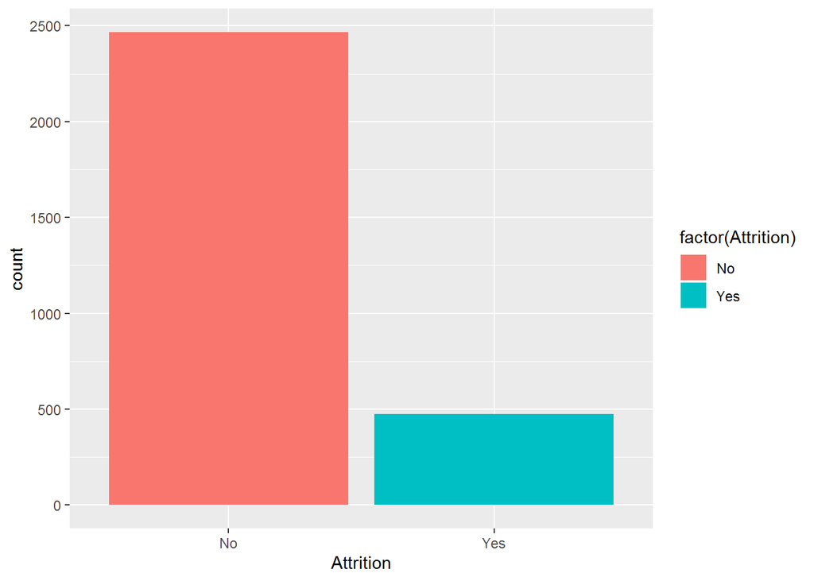

```r
ggplot(hrdata, aes(Attrition, fill=factor(Attrition))) + geom_bar()
```

Out of 2940 employees, 474 (16.12%) moved out and 2466 (83.87%) continued with the employer.

See how the attrition varies based on age.

```r
table(hrdata$Age, hrdata$Attrition)
```

```
##
##       No Yes
##   18   8   8
##   19   6  12
##   20  10  12
##   21  14  12
##   22  22  10
##   23  20   8
##   24  38  14
##   25  40  12
##   26  54  24
##   27  90   6
##   28  68  28
##   29 100  36
##   30 102  18
```

[output cut: 30 more lines]

```r
prop.table(table(hrdata$Age, hrdata$Attrition))
```

```
##
##               No         Yes
##   18 0.002721088 0.002721088
##   19 0.002040816 0.004081633
##   20 0.003401361 0.004081633
##   21 0.004761905 0.004081633
##   22 0.007482993 0.003401361
##   23 0.006802721 0.002721088
##   24 0.012925170 0.004761905
##   25 0.013605442 0.004081633
##   26 0.018367347 0.008163265
##   27 0.030612245 0.002040816
##   28 0.023129252 0.009523810
##   29 0.034013605 0.012244898
##   30 0.034693878 0.006122449
```

[output cut: 30 more lines]

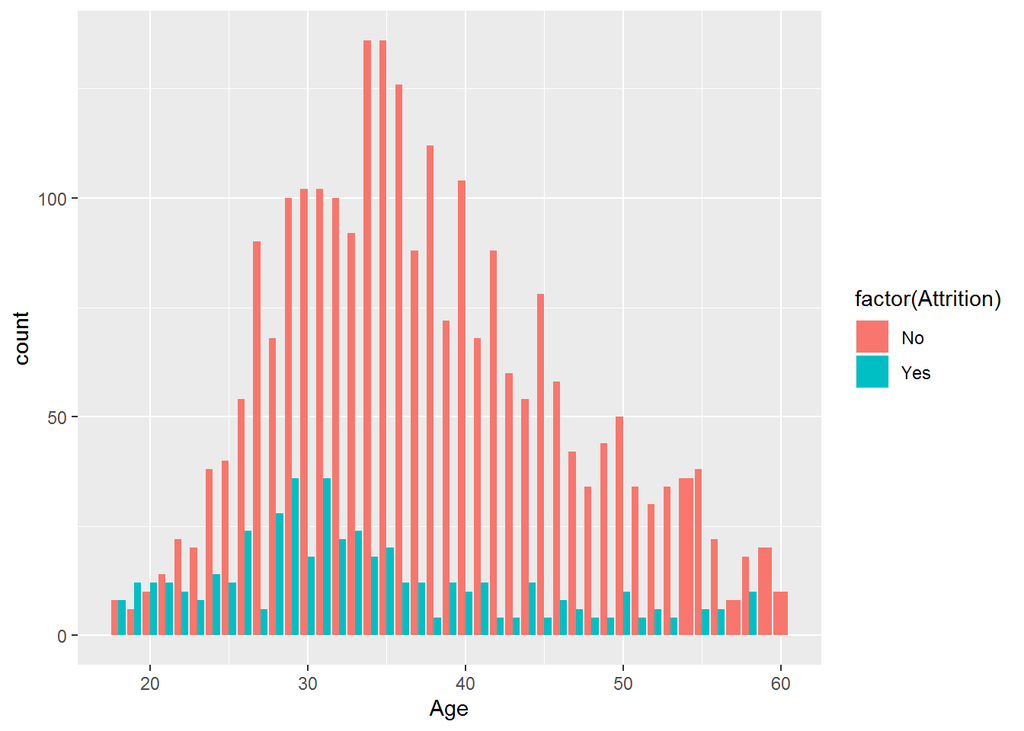

```r
ggplot(hrdata, aes(Age, ..count.., fill = factor(Attrition))) + geom_bar(position="dodge")
```

The number of people who moved out are pretty big in the age ranging from 26 to 35. No one moved out after 58.

See how the attrition varies based on hourly rate.

```r
table(hrdata$HourlyRate, hrdata$Attrition)
```

```
##
##       No Yes
##   30  38   0
##   31  26   4
##   32  40   8
##   33  32   6
##   34  14  10
##   35  34   2
##   36  26  10
##   37  30   6
##   38  18   8
##   39  26   8
##   40  32   4
##   41  38   4
##   42  56   0
```

[output cut: 58 more lines]

```r
prop.table(table(hrdata$HourlyRate, hrdata$Attrition))
```

```
##
##                 No          Yes
##   30  0.0129251701 0.0000000000
##   31  0.0088435374 0.0013605442
##   32  0.0136054422 0.0027210884
##   33  0.0108843537 0.0020408163
##   34  0.0047619048 0.0034013605
##   35  0.0115646259 0.0006802721
##   36  0.0088435374 0.0034013605
##   37  0.0102040816 0.0020408163
##   38  0.0061224490 0.0027210884
##   39  0.0088435374 0.0027210884
##   40  0.0108843537 0.0013605442
##   41  0.0129251701 0.0013605442
##   42  0.0190476190 0.0000000000
```

[output cut: 58 more lines]

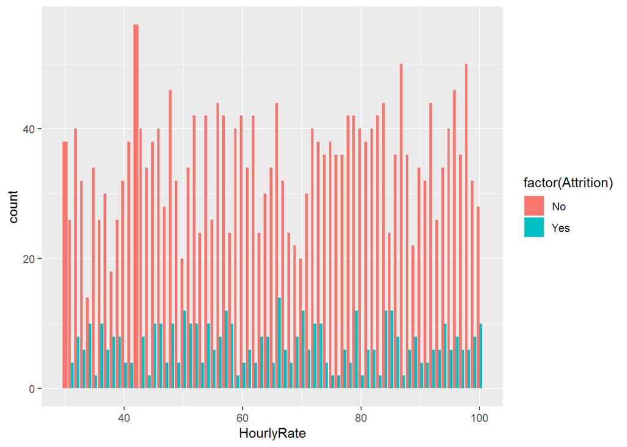

```r
ggplot(hrdata, aes(HourlyRate, ..count.., fill = factor(Attrition))) + geom_bar(position="dodge")
```

There is attrition in all the ranges of hourly rate. It is not like employees with particular hourly rate will move out.

See how the attrition varies based on job role.

```r
table(hrdata$JobRole, hrdata$Attrition)
```

```
##
##                              No Yes
##   Healthcare Representative 244  18
##   Human Resources            80  24
##   Laboratory Technician     394 124
##   Manager                   194  10
##   Manufacturing Director    270  20
##   Research Director         156   4
##   Research Scientist        490  94
##   Sales Executive           538 114
##   Sales Representative      100  66
```

```r
prop.table(table(hrdata$JobRole, hrdata$Attrition))
```

```
##
##                                      No         Yes
##   Healthcare Representative 0.082993197 0.006122449
##   Human Resources           0.027210884 0.008163265
##   Laboratory Technician     0.134013605 0.042176871
##   Manager                   0.065986395 0.003401361
##   Manufacturing Director    0.091836735 0.006802721
##   Research Director         0.053061224 0.001360544
##   Research Scientist        0.166666667 0.031972789
##   Sales Executive           0.182993197 0.038775510
##   Sales Representative      0.034013605 0.022448980
```

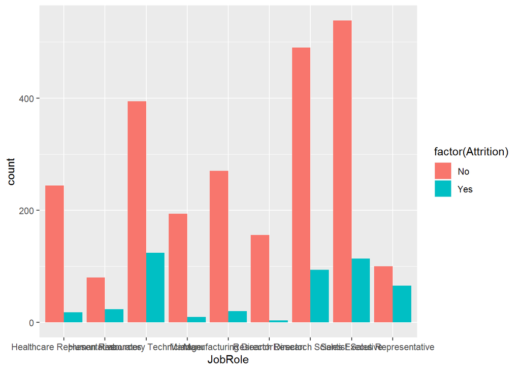

```r
ggplot(hrdata, aes(JobRole, ..count.., fill = factor(Attrition))) + geom_bar(position="dodge")
```

More attrition is observed in Lab Technicians followed by Sales Executives, Research Scientists and Sales Representatives in order.

See how the attrition varies based on monthly income.

```r
table(hrdata$MonthlyIncome, hrdata$Attrition)
```

```
##
##         No Yes
##   1009   0   2
##   1051   2   0
##   1052   2   0
##   1081   0   2
##   1091   0   2
##   1102   0   2
##   1118   0   2
##   1129   2   0
##   1200   2   0
##   1223   2   0
##   1232   2   0
##   1261   0   2
##   1274   2   0
```

[output cut: 1336 more lines]

```r
prop.table(table(hrdata$MonthlyIncome, hrdata$Attrition))
```

```
##
##                   No          Yes
##   1009  0.0000000000 0.0006802721
##   1051  0.0006802721 0.0000000000
##   1052  0.0006802721 0.0000000000
##   1081  0.0000000000 0.0006802721
##   1091  0.0000000000 0.0006802721
##   1102  0.0000000000 0.0006802721
##   1118  0.0000000000 0.0006802721
##   1129  0.0006802721 0.0000000000
##   1200  0.0006802721 0.0000000000
##   1223  0.0006802721 0.0000000000
##   1232  0.0006802721 0.0000000000
##   1261  0.0000000000 0.0006802721
##   1274  0.0006802721 0.0000000000
```

[output cut: 1336 more lines]

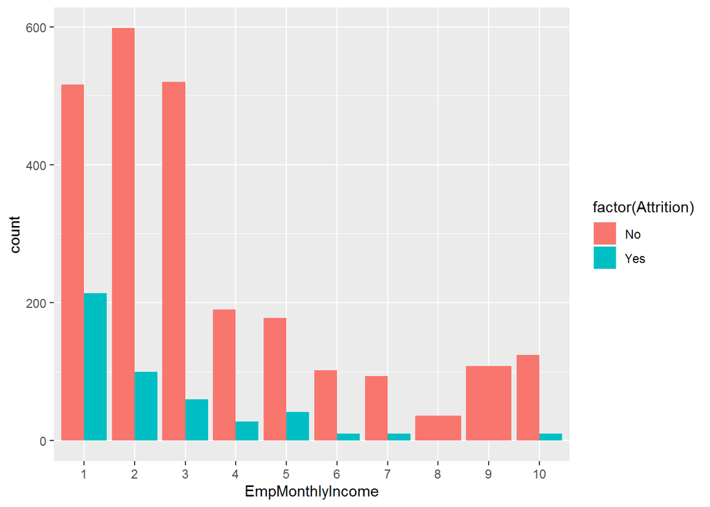

```r
EmpMonthlyIncome <- cut(hrdata$MonthlyIncome, 10, include.lowest = TRUE, labels=c(1,2,3,4,5,6,7,8,9,10))
ggplot(hrdata, aes(EmpMonthlyIncome, ..count.., fill = factor(Attrition))) + geom_bar(position="dodge")
```

Attrition is more when monthly income is less and it is decreasing with increase in monthly income. So monthly income is contributing to attrition.

See how the attrition varies based on over time.

```r
table(hrdata$OverTime)
```

```
##
##   No  Yes
## 2108  832
```

```r
table(hrdata$OverTime, hrdata$Attrition)
```

```
##
##         No  Yes
##   No  1888  220
##   Yes  578  254
```

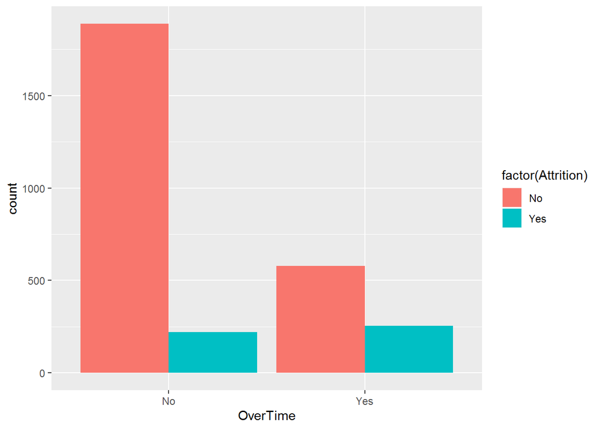

```r
ggplot(hrdata, aes(OverTime, ..count.., fill = factor(Attrition))) + geom_bar(position="dodge")
```

832(28.29%) employs are putting overtime. 254(30.5%) employs out of 832 who put overtime moved out. 220(10.43%) out of 2108 who don’t put overtime employs moved out. The attrition percent is more in the employs who put overtime. Hence overtime is contributing to attrition.

See how the attrition varies based on total working years.

```r
table(hrdata$TotalWorkingYears, hrdata$Attrition)
```

```
##
##       No Yes
##   0   12  10
##   1   82  80
##   2   44  18
##   3   66  18
##   4  102  24
##   5  144  32
##   6  206  44
##   7  126  36
##   8  174  32
##   9  172  20
##   10 354  50
##   11  58  14
##   12  86  10
```

[output cut: 27 more lines]

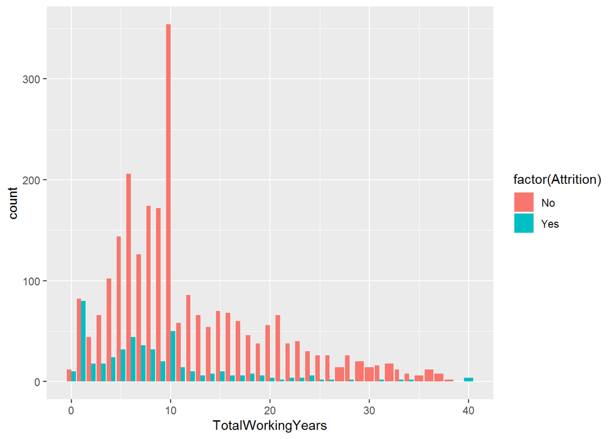

```r
ggplot(hrdata, aes(TotalWorkingYears, ..count.., fill = factor(Attrition))) + geom_bar(position="dodge")
```

The employs are moving out more up to 10 years of experience. The attrition after 10 years of total working years is very low.

See how the attrition varies based on distance from home.

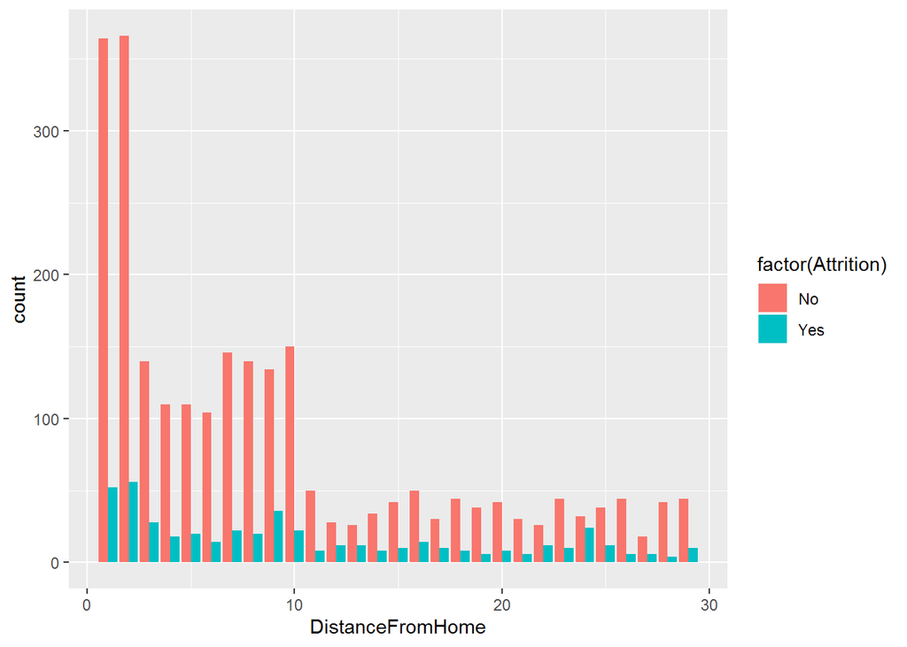

```r
ggplot(hrdata, aes(DistanceFromHome, ..count.., fill = factor(Attrition))) + geom_bar(position="dodge")
```

The is more attrition who are nearby up to 10 km. Attrition is decreasing with increasing distance till 29 km.

See how the attrition varies based on number of companies worked.

```r
table(hrdata$NumCompaniesWorked)
```

```
##
##    0    1    2    3    4    5    6    7    8    9
##  394 1042  292  318  278  126  140  148   98  104
```

```r
table(hrdata$NumCompaniesWorked, hrdata$Attrition)
```

```
##
##      No Yes
##   0 348  46
##   1 846 196
##   2 260  32
##   3 286  32
##   4 244  34
##   5  94  32
##   6 108  32
##   7 114  34
##   8  86  12
##   9  80  24
```

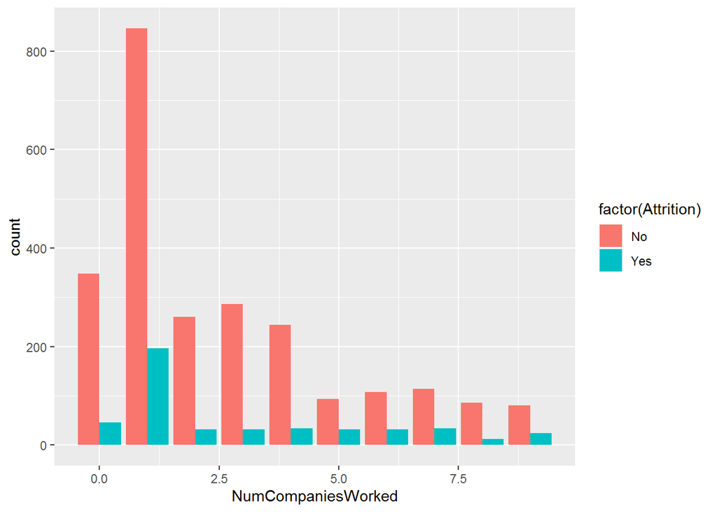

```r
ggplot(hrdata, aes(NumCompaniesWorked, ..count.., fill = factor(Attrition))) + geom_bar(position="dodge")
```

More number of employs moving out are in 0 or 1 category. Current employer is either 1st or 2nd employer for them.

See how the attrition varies based on percent salary hike.

```r
table(hrdata$PercentSalaryHike)
```

```
##
##  11  12  13  14  15  16  17  18  19  20  21  22  23  24  25
## 420 396 418 402 202 156 164 178 152 110  96 112  56  42  36
```

```r
table(hrdata$PercentSalaryHike, hrdata$Attrition)
```

```
##
##       No Yes
##   11 338  82
##   12 330  66
##   13 350  68
##   14 354  48
##   15 166  36
##   16 128  28
##   17 136  28
##   18 152  26
##   19 134  18
##   20  96  14
##   21  86  10
##   22  88  24
##   23  44  12
##   24  30  12
##   25  34   2
```

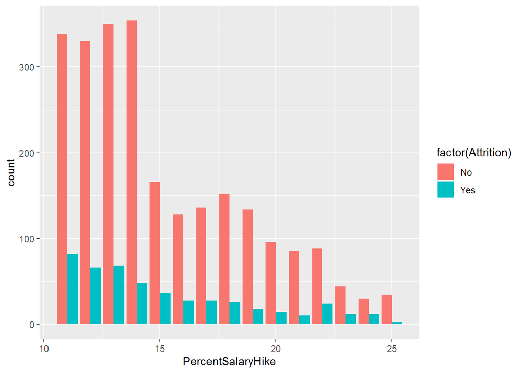

```r
ggplot(hrdata, aes(PercentSalaryHike, ..count.., fill = factor(Attrition))) + geom_bar(position="dodge")
```

More attrition is observed for lesser the salary percent hikes.

See how the attrition varies based on performance rating.

```r
table(hrdata$PerformanceRating)
```

```
##
##    3    4
## 2488  452
```

```r
prop.table(table(hrdata$PerformanceRating))
```

```
##
##         3         4
## 0.8462585 0.1537415
```

```r
table(hrdata$PerformanceRating, hrdata$Attrition)
```

```
##
##       No  Yes
##   3 2088  400
##   4  378   74
```

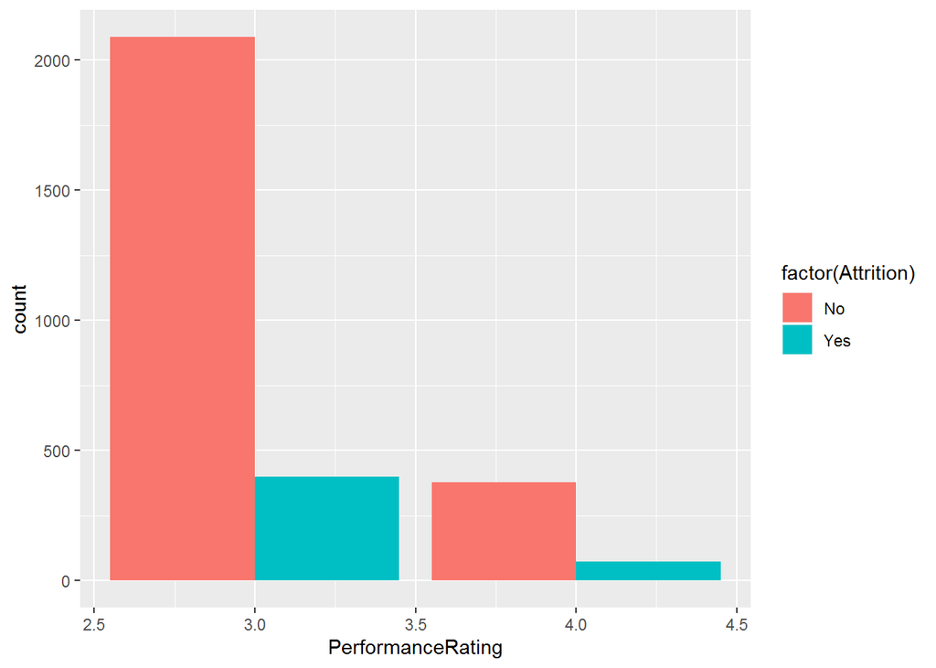

```r
ggplot(hrdata, aes(PerformanceRating, ..count.., fill = factor(Attrition))) + geom_bar(position="dodge")
```

See how the attrition varies based on work life balance.

```r
table(hrdata$WorkLifeBalance)
```

```
##
##    1    2    3    4
##  160  688 1786  306
```

```r
prop.table(table(hrdata$WorkLifeBalance))
```

```
##
##          1          2          3          4
## 0.05442177 0.23401361 0.60748299 0.10408163
```

```r
table(hrdata$WorkLifeBalance, hrdata$Attrition)
```

```
##
##       No  Yes
##   1  110   50
##   2  572  116
##   3 1532  254
##   4  252   54
```

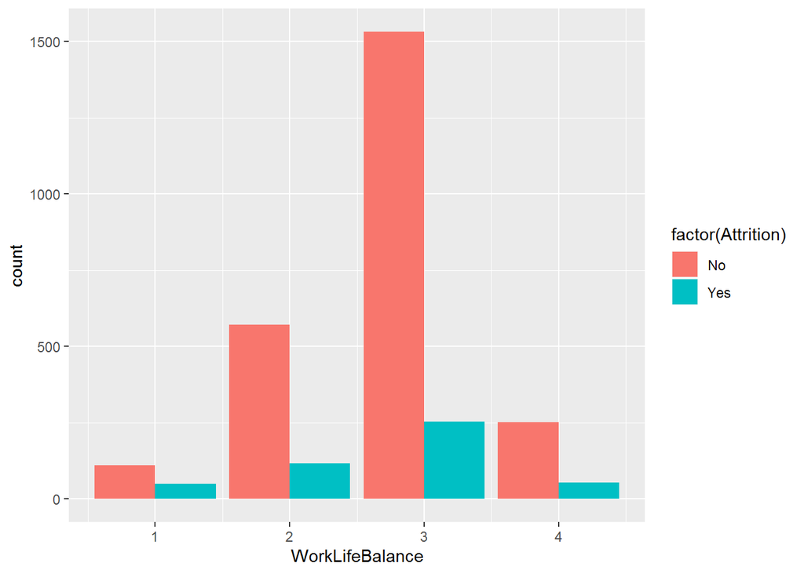

```r
ggplot(hrdata, aes(WorkLifeBalance, ..count.., fill = factor(Attrition))) + geom_bar(position="dodge")
```

50(31.25%) of 160 employs who don’t have work life balance have moved out. This shows that work life balance contributes to attrition.

See how the attrition varies based on years at company.

```r
table(hrdata$YearsAtCompany, hrdata$Attrition)
```

```
##
##       No Yes
##   0   56  32
##   1  224 118
##   2  200  54
##   3  216  40
##   4  182  38
##   5  350  42
##   6  134  18
##   7  158  22
##   8  142  18
##   9  148  16
##   10 204  36
##   11  60   4
##   12  28   0
```

[output cut: 24 more lines]

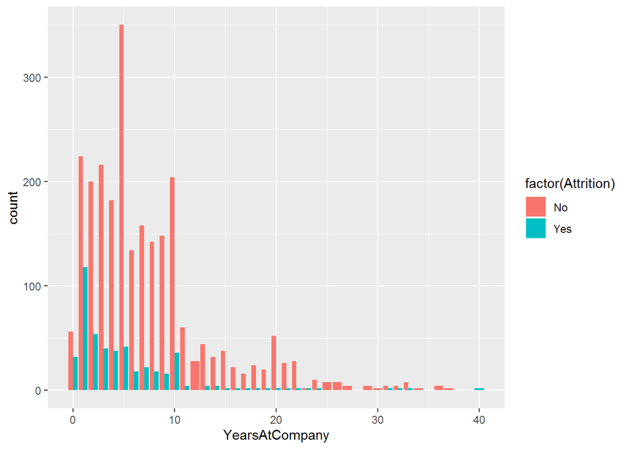

```r
ggplot(hrdata, aes(YearsAtCompany, ..count.., fill = factor(Attrition))) + geom_bar(position="dodge")
```

More attrition is up to 10 years. From above graph, it is observed that there are very a smaller number of people who move out after staying with an employer for more than 10 years.

See how the attrition varies based on years in current role.

```r
table(hrdata$YearsInCurrentRole, hrdata$Attrition)
```

```
##
##       No Yes
##   0  342 146
##   1   92  22
##   2  608 136
##   3  238  32
##   4  178  30
##   5   70   2
##   6   70   4
##   7  382  62
##   8  164  14
##   9  122  12
##   10  54   4
##   11  44   0
##   12  18   2
##   13  26   2
##   14  20   2
##   15  12   4
##   16  14   0
##   17   8   0
##   18   4   0
```

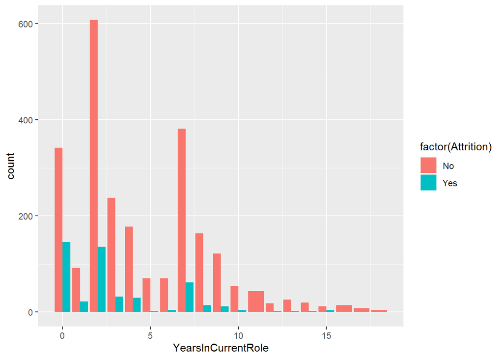

```r
ggplot(hrdata, aes(YearsInCurrentRole, ..count.., fill = factor(Attrition))) + geom_bar(position="dodge")
```

More number of people are moving out when they are in same role up to 10 years.

See how the attrition varies based on years since last promotion.

```r
table(hrdata$YearsSinceLastPromotion, hrdata$Attrition)
```

```
##
##       No Yes
##   0  942 220
##   1  616  98
##   2  264  54
##   3   86  18
##   4  112  10
##   5   86   4
##   6   52  12
##   7  120  32
##   8   36   0
##   9   26   8
##   10  10   2
##   11  44   4
##   12  20   0
##   13  16   4
##   14  16   2
##   15  20   6
```

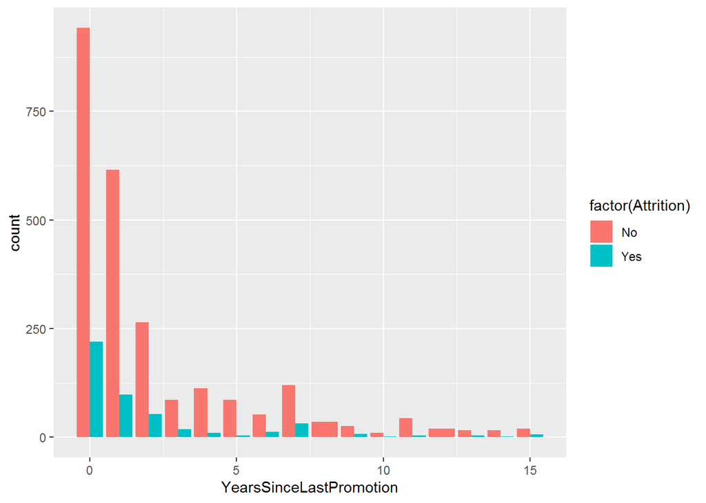

```r
ggplot(hrdata, aes(YearsSinceLastPromotion, ..count.., fill = factor(Attrition))) + geom_bar(position="dodge")
```

More number of people are moving out up to 7 years since last promotion.

See how the attrition varies based on years with current manager.

```r
table(hrdata$YearsWithCurrManager, hrdata$Attrition)
```

```
##
##       No Yes
##   0  356 170
##   1  130  22
##   2  588 100
##   3  246  38
##   4  174  22
##   5   54   8
##   6   50   8
##   7  370  62
##   8  194  20
##   9  116  12
##   10  48   6
##   11  42   2
##   12  36   0
##   13  28   0
##   14   6   4
##   15  10   0
##   16   4   0
##   17  14   0
```

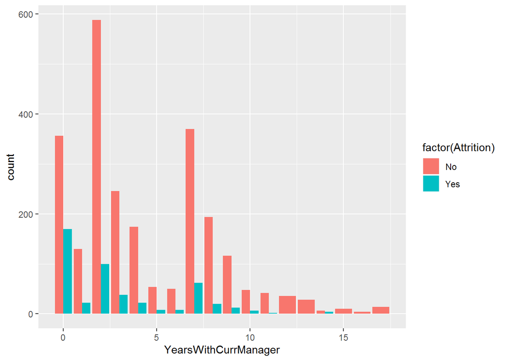

```r
ggplot(hrdata, aes(YearsWithCurrManager, ..count.., fill = factor(Attrition))) + geom_bar(position="dodge")
```

Attrition is less when the employ stays with same manager for more time.

**Identify variables which are of no use and remove them**

Identify variables with zero variance and see that value

```r
nearZeroVar(hrdata)
```

```
## [1]  9 22 27
```

```r
Filter(function(x)(length(unique(x))==1), hrdata)
```

```
##      EmployeeCount Over18 StandardHours
## 1                1      Y            80
## 2                1      Y            80
## 3                1      Y            80
## 4                1      Y            80
## 5                1      Y            80
## 6                1      Y            80
## 7                1      Y            80
## 8                1      Y            80
## 9                1      Y            80
## 10               1      Y            80
## 11               1      Y            80
## 12               1      Y            80
## 13               1      Y            80
## 14               1      Y            80
```

[output cut: 2926 more lines]

The columns EmployeeCount, Over18 and StandardHours has only one value throughout the dataset. The value is 1, Y and 80 respectively.

Remove the above identified columns as they have only one value through out and will not be useful for our analysis. EmployeeNumber column acts as an identifier and does not contribute to variance. So remove that as well.

```r
#EmployeeCount,Over18,StandardHours have zero variance.
#They containonly one value 1,Y and 80 respectively.
#EmployeeNumber is an identifier and is not required for our analysis

hrdata$EmployeeCount <- NULL
hrdata$Over18 <- NULL
hrdata$StandardHours <- NULL
hrdata$EmployeeNumber <- NULL
```

Check the dimensions of the data and verify if the columns are removed.

```r
dim(hrdata)
```

```
## [1] 2940   31
```

```r
dim(hreaData)
```

```
## [1] 2940   35
```

```r
names(hrdata)
```

```
##  [1] "Age"                      "Attrition"
##  [3] "BusinessTravel"           "DailyRate"
##  [5] "Department"               "DistanceFromHome"
##  [7] "Education"                "EducationField"
##  [9] "EnvironmentSatisfaction"  "Gender"
## [11] "HourlyRate"               "JobInvolvement"
## [13] "JobLevel"                 "JobRole"
## [15] "JobSatisfaction"          "MaritalStatus"
## [17] "MonthlyIncome"            "MonthlyRate"
## [19] "NumCompaniesWorked"       "OverTime"
## [21] "PercentSalaryHike"        "PerformanceRating"
## [23] "RelationshipSatisfaction" "StockOptionLevel"
## [25] "TotalWorkingYears"        "TrainingTimesLastYear"
## [27] "WorkLifeBalance"          "YearsAtCompany"
## [29] "YearsInCurrentRole"       "YearsSinceLastPromotion"
## [31] "YearsWithCurrManager"
```

```r
nrow(hrdata)
```

```
## [1] 2940
```

## Split the dataset in to dev and holdout samples (70:30)

Split the given dataset in to dev and holdout samples in the ratio 70:30.

```r
set.seed(100)

#Split the sample
split = sample.split(hrdata$Attrition, SplitRatio = 0.70)

# Create training and testing sets
hrdata_dev = subset(hrdata, split == TRUE)
hrdata_holdout = subset(hrdata, split == FALSE)
```

Verify if the data is split accordingly and is evenly distributed.

```r
#Check dimensions of datasets
dim(hrdata_dev)
```

```
## [1] 2058   31
```

```r
dim(hrdata_holdout)
```

```
## [1] 882  31
```

```r
dim(hrdata)
```

```
## [1] 2940   31
```

```r
#Check how attrition is distributed in dev sample
table(hrdata_dev$Attrition)
```

```
##
##   No  Yes
## 1726  332
```

```r
prop.table(table(hrdata_dev$Attrition))
```

```
##
##        No       Yes
## 0.8386783 0.1613217
```

```r
#Check how attrition is distributed in holdout sample
table(hrdata_holdout$Attrition)
```

```
##
##  No Yes
## 740 142
```

```r
prop.table(table(hrdata_holdout$Attrition))
```

```
##
##        No       Yes
## 0.8390023 0.1609977
```

```r
#Check how attrition is distributed in original data sample
table(hrdata$Attrition)
```

```
##
##   No  Yes
## 2466  474
```

```r
prop.table(table(hrdata$Attrition))
```

```
##
##        No       Yes
## 0.8387755 0.1612245
```

```r
set.seed(100)
```

Dev sample has 2058 records which is 70% of 2940. Holdout sample has 882 records which is 30% of 2940. So, the samples are split in 70:30 ratio. And the percent of employ attrition is around 16% in dev, holdout and original sample. So, the attrition data is distributed properly after splitting the dataset in to new sets for analysis.

## Build CART Model on dev sample and validate the model built on holdout sample

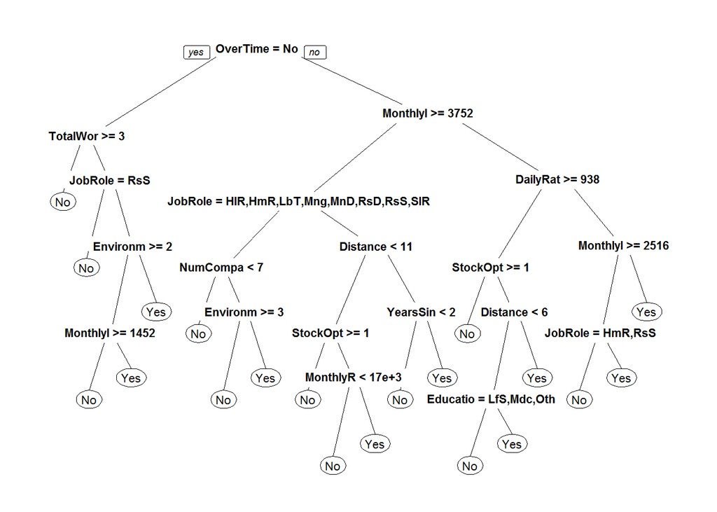

```r
modelCart = rpart(Attrition ~ ., data=hrdata_dev, method="class")
#Plot the model
prp(modelCart)
```

```r
#Predict the test data
predictionCart <- predict(modelCart, newdata=hrdata_holdout, type="class")

#Confusion matrix
confmatCart <- table(hrdata_holdout$Attrition, predictionCart)
confmatCart
```

```
##      predictionCart
##        No Yes
##   No  718  22
##   Yes  93  49
```

```r
#Both Actual & Predicted No
confmatCart[1]
```

```
## [1] 718
```

```r
#Both Actual & Predicted Yes
confmatCart[4]
```

```
## [1] 49
```

```r
#CART model accuracy
(confmatCart[1]+confmatCart[4])/(nrow(hrdata_holdout))
```

```
## [1] 0.8696145
```

## Build Neural Network on dev sample and validate the model built on holdout sample

```r
set.seed(100)

#Build Neural Network on dev
modelNN<-nnet(Attrition~.,hrdata_dev,size=21,rang=0.07,Hess=FALSE,decay=15e-4,maxit=2000)
```

[output not shown]

[output cut: 46 more lines]

[output not shown]

```r
#Predict on test data
predictionNN<-predict(modelNN,hrdata_holdout,type=("class"))
table(predictionNN)
```

```
## predictionNN
##  No Yes
## 772 110
```

```r
#Counfusion Matrix
confmatNN <- table(hrdata_holdout$Attrition, predictionNN)
confmatNN
```

```
##      predictionNN
##        No Yes
##   No  705  35
##   Yes  67  75
```

```r
#Both Actual & Predicted No
confmatNN[1]
```

```
## [1] 705
```

```r
#Both Actual & Predicted Yes
confmatNN[4]
```

```
## [1] 75
```

```r
#NeuralNetwork model accuracy
(confmatNN[1]+confmatNN[4])/(nrow(hrdata_holdout))
```

```
## [1] 0.8843537
```

## Improvise the NN model and validate the new model on holdout sample

```r
set.seed(100)

#Build Neural Network to improve the previous one
modelNN_imp<-nnet(Attrition~.,hrdata_dev,size=21,rang=0.07,Hess=FALSE,decay=15e-4,maxit=6000)
```

[output not shown]

[output cut: 446 more lines]

[output not shown]

```r
#Predict on test data
predictionNN_imp<-predict(modelNN_imp,hrdata_holdout,type=("class"))
table(predictionNN_imp)
```

```
## predictionNN_imp
##  No Yes
## 741 141
```

```r
#Counfusion Matrix
confmatNN_imp <- table(hrdata_holdout$Attrition, predictionNN_imp)
confmatNN_imp
```

```
##      predictionNN_imp
##        No Yes
##   No  711  29
##   Yes  30 112
```

```r
#Both Actual & Predicted No
confmatNN_imp[1]
```

```
## [1] 711
```

```r
#Both Actual & Predicted Yes
confmatNN_imp[4]
```

```
## [1] 112
```

```r
#NeuralNetwork model accuracy
(confmatNN_imp[1]+confmatNN_imp[4])/(nrow(hrdata_holdout))
```

```
## [1] 0.9331066
```

NN model outperforms CART model and hence preferred.